# **Updated Penguin Measurements!**

M. Roberts

2025-08-29

# Figures

**Let’s create a scatter plot looking at the relationship between body mass and bill length in Gentoo penguins**

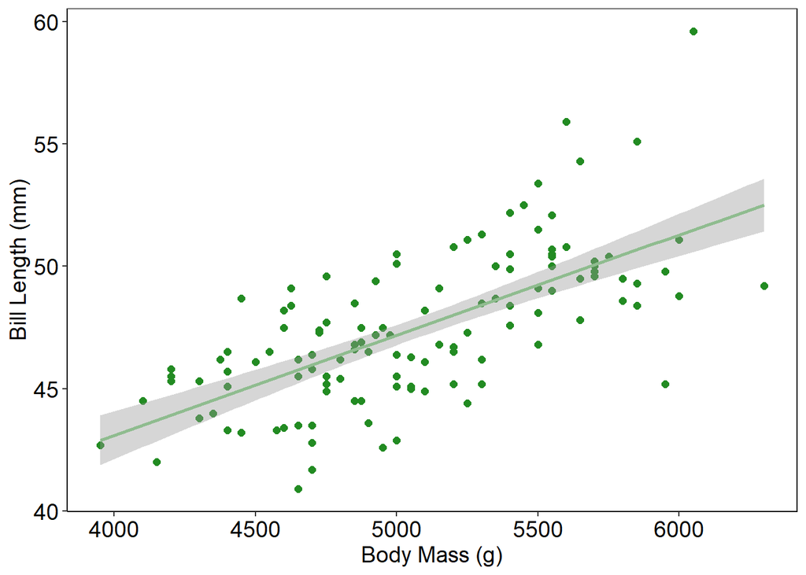

*Fig 1. Scatterplot visualizing the relationship bewteen body mass(g) and bill length(mm) of Gentoo penguins including the 95% confidence intervals.*

```r
gentoo_data <- penguins %>%
               filter(species == "Gentoo",
                      !is.na(bill_length_mm),
                      !is.na(body_mass_g))


bm_bl_scatterplot_gentoo <- ggplot(gentoo_data, aes(x = body_mass_g, y = bill_length_mm)) +
                                   geom_point(size = 2, color = "forestgreen") +
                                   geom_smooth(method = "lm", se = TRUE, color = "darkseagreen") +
                                   labs(x = "Body Mass (g)",
                                        y = "Bill Length (mm)") +
                                   theme_classic() +
                                   theme(panel.border = element_rect(fill = NA))+
                                   theme(axis.text = element_text(size=14, color = "black"),
                                   axis.title = element_text(size=14))

bm_bl_scatterplot_gentoo
```

```r
ggsave("ghb_figures/bm_bl_scatterplot_gentoo.png")
```

**Now let’s make bar plot looking at sex and mean flipper length in Chinstrap penguins**

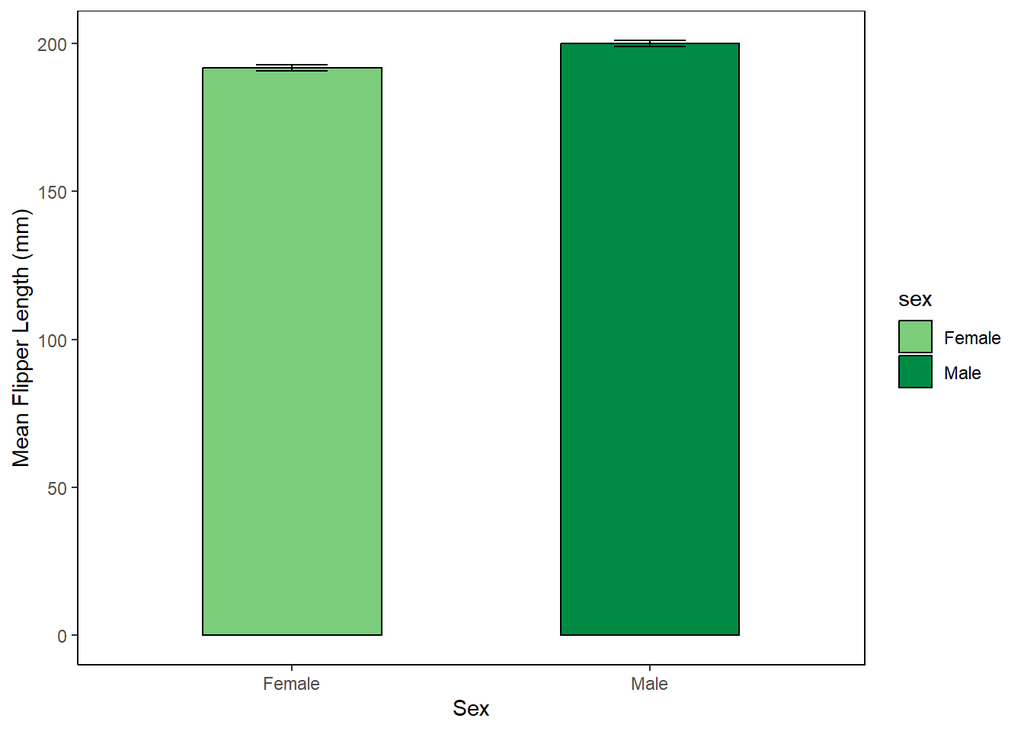

*Fig 2. Bar plot comparison of mean flipper length(mm) between females and males in Chinstrap penguins; bars show mean +/- SE.*

```r
chinstrap_data <- penguins %>%
                  filter(species == "Chinstrap",
                      !is.na(sex),
                      !is.na(flipper_length_mm))

fl_mean <- chinstrap_data %>%
           group_by(sex) %>%
           summarise(fl_mean = mean(flipper_length_mm),
                      fl_se  = sd(flipper_length_mm)/sqrt(n()))


sex_mfl_barplot_chinstrap <- ggplot(fl_mean, aes(x = sex, y = fl_mean, fill = sex)) +
                                    geom_bar(stat='identity', color = "black", width = 0.5) +
                                    geom_errorbar(aes(ymin = fl_mean - fl_se, ymax = fl_mean + fl_se),
                                    width = 0.2, linewidth = 0.4 ) +
                                    scale_x_discrete(labels = c("female" = "Female", "male" = "Male")) +
                                    scale_fill_manual(values = c("male" = "springgreen4", "female" = "palegreen3"),
                                                      labels = c("male" = "Male", "female" = "Female")) +
                                    theme_bw() +
                                    theme_classic() +
                                    theme(panel.border = element_rect(fill = NA)) +
                                    labs(x = "Sex") +
                                    labs(y = "Mean Flipper Length (mm)")

sex_mfl_barplot_chinstrap
```

```r
ggsave("ghb_figures/sex_mfl_barplot_chinstrap.png")
```

**Now that we have created a bar plot, let’s make a histogram looking at bill depth of Adelie penguins**

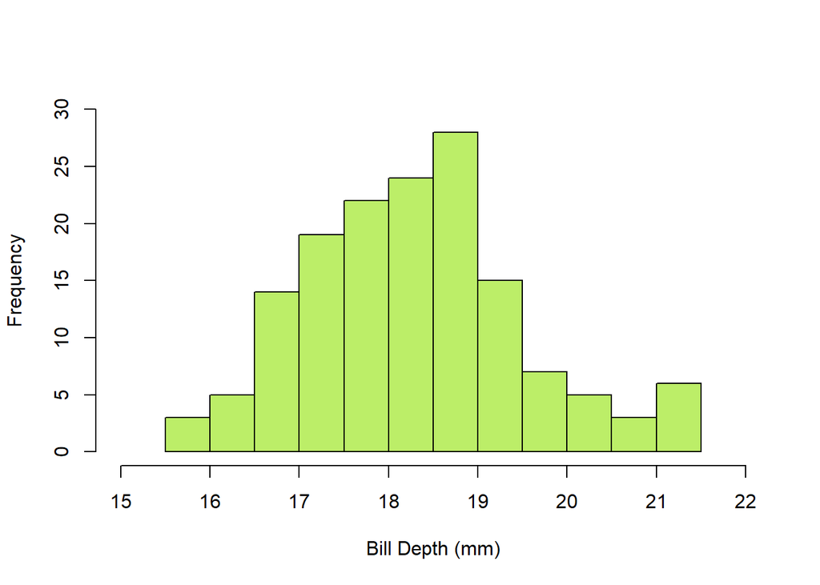

*Fig 3. Distribution of bill depths(mm) in Adelie penguins.*

```r
adelie_data <- penguins %>%
               filter(species == "Adelie",
                      !is.na(bill_depth_mm))

bd_hist_adelie <- hist(adelie_data$bill_depth_mm,
                       col = "darkolivegreen2",
                       xlab = "Bill Depth (mm)",
                       xlim = c(15, 22),
                       ylim = c(0, 30),
                       main = "")
```

# Tables

**Let’s dive into some tables looking at yearly means of bill length and bill depth with standard deviation in Gentoo penguins**

```r
gentoo_data <- penguins %>%
               filter(species == "Gentoo",
                      !is.na(bill_length_mm),
                      !is.na(bill_depth_mm))

means_sd_yearly <- gentoo_data %>%
                   group_by(year) %>%
                   summarise("Mean Bill Length (mm)" = round(mean(bill_length_mm), 2),
                             "SD Bill Length (mm)" = round(sd(bill_length_mm), 2),
                             "Mean Bill Depth (mm)" = round(mean(bill_depth_mm), 2),
                             "SD Bill Depth (mm)" = round(sd(bill_depth_mm), 2),
                             ) %>%
                             rename(Year = year)

kable(means_sd_yearly, caption = 'Table 1. A summary of yearly means of bill lengths and bill depths including standard deviation in Gentoo Penguins.')
```

Table 1. A summary of yearly means of bill lengths and bill depths including standard deviation in Gentoo Penguins.

| Year | Mean Bill Length (mm) | SD Bill Length (mm) | Mean Bill Depth (mm) | SD Bill Depth (mm) |
| --- | --- | --- | --- | --- |
| 2007 | 47.01 | 3.27 | 14.69 | 0.91 |
| 2008 | 46.94 | 2.64 | 14.92 | 0.99 |
| 2009 | 48.50 | 3.19 | 15.28 | 0.97 |

**Now that we have looked at some yearly data for Gentoo penguins, let’s turn our focus to the individual islands. We are now going to make a table looking at some variables for each island for Adelie penguins**

```r
adelie_data <- penguins %>%
               filter(species == "Adelie",
                      !is.na(body_mass_g))

means_sd_max_min_island <- adelie_data %>%
                           group_by(island) %>%
                           summarise("Mean Body Mass (g)" = round(mean(body_mass_g), 2),
                                     "SD Body Mass (g)" = round(sd(body_mass_g), 2),
                                     "Maximum Body Mass (g)" = max(body_mass_g),
                                     "Minimum Body Mass (g)" = min(body_mass_g),
                                     ) %>%
                                     rename(Island = island)

kable(means_sd_max_min_island, caption = 'Table 2. A summary of body mass measurements of Adelie penguins on different islands.')
```

Table 2. A summary of body mass measurements of Adelie penguins on different islands.

| Island | Mean Body Mass (g) | SD Body Mass (g) | Maximum Body Mass (g) | Minimum Body Mass (g) |
| --- | --- | --- | --- | --- |
| Biscoe | 3709.66 | 487.73 | 4775 | 2850 |
| Dream | 3688.39 | 455.15 | 4650 | 2900 |
| Torgersen | 3706.37 | 445.11 | 4700 | 2900 |

# Maps

**After we have created some tables, let’s visualize where these islands and Palmer Station are located on a map**

Biscoe Island is indicated on the map by blue.

Dream Island is indicated on the map by red.

Torgersen Island is indicated on the map by green.

Palmer Station is indicated on the map by orange.

```r
leaflet() %>%
  addTiles() %>%
  addCircleMarkers(lng = -65.92340, lat = -65.73258,
             color = "blue", fill = "blue") %>%
  addCircleMarkers(lng = -64.24054, lat = -64.73097,
             color = "red", fill = "red") %>%
  addCircleMarkers(lng = -64.07895, lat = -64.76612,
             color = "green", fill = "green") %>%
  addCircleMarkers(lng = -64.05357, lat = -64.77419,
             color = "orange", fill = "orange")
```

[interactive chart not shown]

# Video

**Let’s take a look at some penguin interactions in Antarctica during breeding season**

[video not shown]